# MultiChannel Gift Company Sales Campaign and Sales Data Analysis

#### Group 5 Members:

- Wen Liu | 01567098
- Faiz Fablillah | 01525542
- Joyce Zhou | 01619169
- Ying Lan | 01630056

### Content Page

Summary

Introduction

Technologies and Techniques

Cleaning and preparing the data

Results (Analysis, observations and recommendations)

Conclusion

References

# Summary

Below exercise consists of analysis of data provided by multichannel gift company. Datasets consist of information about customers, sales campaign, orders, among other information. Our analysis started with loading and cleaning data from CSV files to PostgresSQL DB. We then analysed the datasets further to see how different types of sales and marketing evolve over time and how different marketing methods impact associated order placement/sales in Christmas and non-Christmas periods. Further analysis involves channel summary of Recency / Frequency / Monetary (RFM) information analysis to find out how the company can target customers properly and effectively. Outcome of the analysis will be used by the company to decide their way forward on marketing campaign in order to maximize gain with better ROI. Analysis was further expanded by adding new dimension to our RFM, known as "interaction" hence, RFMI. Interaction was defined as dimension which explains whether customer responded to campaigns within 7 days after getting catalog and amount of orders placed in that 7 days. This will help the company in designing better strategy for customer relationship management.

# Introduction

Multichannel gift company has provided their sales campaign, sales and customers data for us to perform an in-depth analysis to derive meaningful insights. The insights will highlight in which areas the company is doing well and where it is lacking. Analysis can help in making better decision leading to a better customer relationship management. Among the aims of the assignment are to concentrate on which campaign strategies are working more effectively, which customer locations are giving better returns, ROI calculations for the campaigns, concentrating on RFM dimensions and how to increase sales during non-Christmas months of year. The information derived from the analysis will be utilized to help the company to produce profitable business decisions in future with better ROI on marketing campaigns.

Below we have summarised the list of datasets we received:

**Customer File:** It contains information about 100,051 customers. It mainly contains information about customers such as customers' buying activity during particular seasons and catalog/email counts delivered to customer. It also has overlay demographic and psycographic information about customers collected from vendor and merged into it.

**Contact File:** It has 3,389,329 marketing contact data from 2005-2007. It contains information about which campaign channel was used to contact client and when.

**Order File:** It has 241,366 records about orders placed by customers online or visiting stores from 2001-2007.

All above datasets are provided as simple CSV files which will need to be loaded into PostgreSQL DB after doing cleaning and proper data handling.

**Our analysis has tried to answer the list of below questions:**

- How do different types of sales and marketing evolve over time?
- How do different marketing methods impact associated order placement/sales in Christmas and non-Christmas periods?
- How RFM dimensions impacting performance of particular segment?
- What changes to be made in order to gain greater ROI for money invested in campaigns?
- What other dimensions can impact customers' reaction along with RFM?
- How to use that other dimensions to influence customers hence, improving ROI for campaigns?

# Technologies_and_Techniques

Below are list of technologies and libraries used for doing analysis:

- **SQL** : SQL was primary technology used for doing analysis and producing results. Data is loaded into PostgreSQL using SQL and various tables were joined and summarised to produced meaningful insights.
- **Pandas** - Pandas is used to for loading data into DB.
- **sqlachemy/psycopg2** - Both provides interface for connecting to PostgreSQL which will be used by Pandas for interacting with DB.
- **matplotlib/seaborn** - Both are used for visualising Results.
- **datetime** - For handling datetime/timestamp datasets.
- **Tableu** - For selected chart production.

```python
import pandas as pd
import datetime
import sqlalchemy
import psycopg2
from sqlalchemy import create_engine
import matplotlib.pyplot as plt
import numpy as np
import seaborn as sns; sns.set()
```

# Cleaning_and_Preparing_the_Data

Cleaning and preparing data involves loading data into PostgreSQL database in proper format and data type for each field involved. Below are some of the steps involved while loading data into DB:

- Loading data into memory using Pandas.
- Cleaning data to remove duplicate/unwanted entries.
- Cleaning data to handle NaNs.
- Handling data types for various fields especially datetime columns.

```python
POSTGRES_ADDRESS = 'localhost'
POSTGRES_PORT = '5432'
POSTGRES_USERNAME = 'postgres'
POSTGRES_PASSWORD = '***'
POSTGRES_DBNAME = 'digital_marketing'
```

```python
postgres_str = ('postgresql://{username}:{password}@{ipaddress}:{port}/{dbname}'.format(username=POSTGRES_USERNAME, password=POSTGRES_PASSWORD, ipaddress=POSTGRES_ADDRESS, port=POSTGRES_PORT, dbname=POSTGRES_DBNAME))
# Create the connection
engine = create_engine(postgres_str)
```

# Results

## 2A. 1 Time series trend and seasonality analysis: how do different types of sales and marketing evolve over time?

##### 1(a) Trend analysis: how do sales from different order method change over time?

Here we conduct the historical time series analysis of different order methods' total sales amount to study its correlation with time. Our key findings are in below:

- Phone has historically been the dominant order method by sales amount
- Internet order has been increasing over the year and has exceeded sales by phone for the first time in 2007
- Store purchasing has also been increasing over the year, and is less affected by seasonality compared to other order methods
- Despite different levels of impact, all four order methods have a hike around Christmas time, indicating more sales volume in Christmas time. This is more significant for phone and internet orders and less significant for mail and shopping mall orders

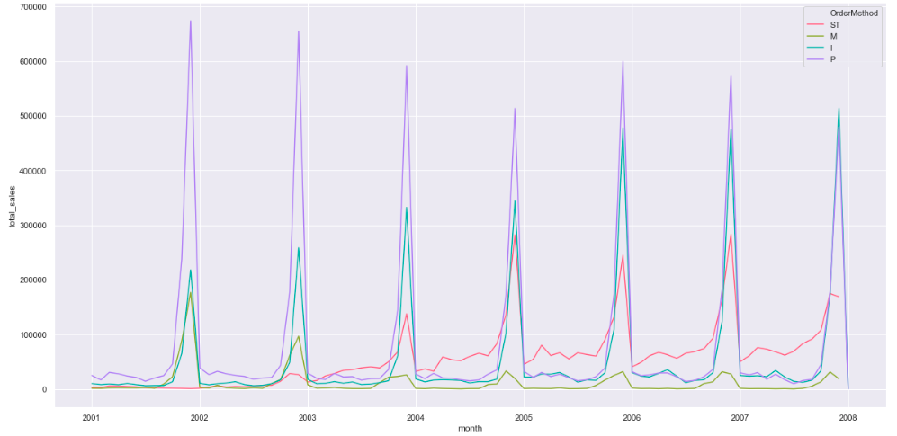

```python
from IPython.display import display, Image
#Sales trend over time in different order methods
display(Image(filename='2a.1.png'))
```

Code:

```
df = pd.read_sql_query('''

SELECT date_trunc('month', l."OrderDate") AS month,
o."OrderMethod",
SUM(l."LineDollars") AS total_sales
FROM dataset9_lines l INNER JOIN dataset9_orders o
ON l."OrderNum" = o."OrderNum"
GROUP BY date_trunc('month', l."OrderDate"), o."OrderMethod"
ORDER BY month ASC


''', cnx)

df.set_index('month')

fig, ax = plt.subplots(figsize=(20, 10))
ax = sns.lineplot(x="month", y="total_sales", hue="OrderMethod", palette=sns.color_palette("husl", 4),
                    data=df)
```

Here we conduct the historical time series analysis of different marketing methods' total contact number to study how the company historically conduct marketing efforts. Our key findings are in below:

- For both email and catalog marketing, there is a strong marketing effort in Christmas season with a hike in contacts
- Catalog marketing has a more stable pattern historically throughout the years. Email marketing tend to change more.

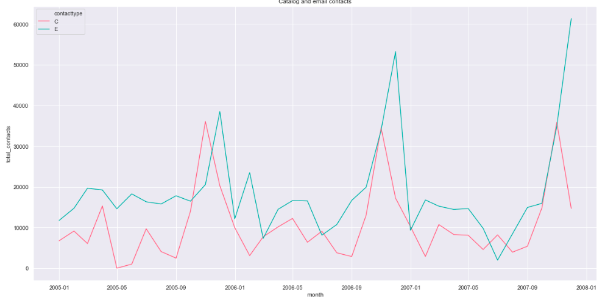

```python
#Contact trend over time in different marketing approaches
display(Image(filename='2a.2.png'))
```

Code:

```
count_contacts=pd.read_csv("2a_1.CSV")
count_contacts.set_index('month')
count_contacts['month']=pd.to_datetime(count_contacts['month'])

fig, ax = plt.subplots(figsize=(20, 10))
plt.title("Catalog and email contacts")
ax = sns.lineplot(x="month", y="total_contacts", hue="contacttype", palette=sns.color_palette("husl", 2),
                    data=count_contacts)
```

Giving that both marketing and order/sales behavior exhibit strong seasonality effect, and there exits different trend patterns of order methods and marketing efforts, it is worthwhile to study the connection between marketing and order/sales behaviors.

As phone (P) and mail (M) are the two methods by which catalog channel orders are placed, and email marketing is most likely to impact internet (I) purchases, we can assume that catalog marketing, if works, is most likely to impact a person to place P and M orders and email marketing is most likely to impact a person to place I orders. THerefore, here comes up with our second analytical question for 2a:

## 2A. 2 How do different marketing methods impact associated order placement/sales in Christmas and non-Christmas periods?

Here we split marketing contacts of the two groups, catalog and email, into different periods, Christmas and non-Christmas seasons. We calculate the orders, number of items purchased as well as spending amount associated with the marketing efforts.

Definitions/assumptions used:

- Associated orders: for catalog shopping, we consider phone and mail orders that are within 7 calendar days of contact dates; for email shopping, we consider internet orders that are within 7 calendar days of contact dates. For store orders/sales, it is difficult to relate it to one specific marketing effort so we do not consider it in this analysis.
- Response rate: total number of associated orders/total number of contacts
- Christmas season: contact date is in between Nov 01 to Dec 24 in 2005-2007.
- NChristmas season: contact date is in between Jan 01 to Oct 31 and post Dec 24 in 2005-2007.

Our key findings are in below:

- For both email and catalog marketing, average number of orders, average number of items purchased and average spending are higher in Christmas season vs Non-Christmas season.
- For catalog marketing, average number of orders, average number of items purchased and average spending is higher than email marketing in both Christmas season vs Non-Christmas season.
- This is mainly due to higher response rate of catalog marketing compared to email marketing. However, from a per response perspective, average spending per response and average items purchased tend to be higher for catalog shopping compared to email shopping, whereas the average number of order placed per response tend to be higher for email marketing. This seem to suggest although email marketing tend to lead to slightly higher number of orders being placed, the items purchased associated with email marketing and the average spendings are less.

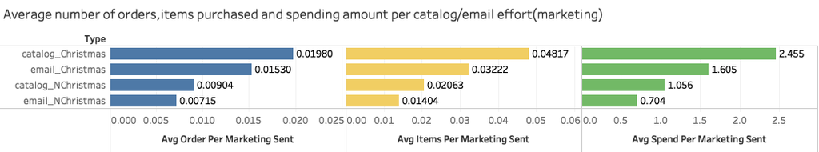

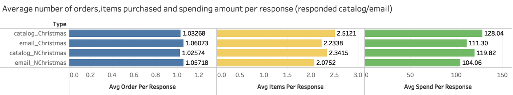

```python
display(Image(filename='2a_3.png'))
display(Image(filename='2a_4.png'))
```

Code:

```
1.  Christmas Catalog data
catalog_shopping: #all the lines associated with catalog shopping (ordermethod=P or M) during the time period 2005-2007
#distinct order number: 30902
#number of items/lines/rows: 61100
CREATE VIEW catalog_shopping AS
(SELECT lines.cust_id,lines.ordernum,lines.orderdate,lines.linedollars,orders.ordermethod,orders.paymenttype FROM
lines INNER JOIN orders
ON lines.ordernum=orders.ordernum
WHERE (ordermethod='P' OR ordermethod='M') AND (lines.orderdate>'2004-12-31' AND lines.orderdate<'2008.01.01')
 )

#30902 orders (distinct ordernum)
CREATE VIEW orders_catalog AS
(SELECT * FROM orders
WHERE (ordermethod='P' OR ordermethod='M') AND (orderdate>'2004-12-31' AND orderdate<'2008.01.01')
 )
Christmas_C_contacts: #all the catalog contacts made around Christmas season in 2005-2007, defined as contacts from Nov-01 to Dec-24
#We noticed that there are catalogs send to the same customer on the same day -> assume this is duplicated data error as it is unlikely to send out two catalog to one customer on the same day, 158525 -> 157967

CREATE VIEW Christmas_C_contacts_not_clean AS
(SELECT *
FROM contacts
WHERE contacttype='C'
AND
((contactdate<='2005-12-24' AND contactdate>='2005-11-01')
 OR (contactdate<='2006-12-24' AND contactdate>='2006-11-01')
 OR (contactdate<='2007-12-24' AND contactdate>='2007-11-01'))
)



CREATE VIEW Christmas_C_contacts AS
(SELECT cust_id, contactdate, contacttype
FROM Christmas_C_contacts_not_clean
GROUP BY cust_id, contactdate, contacttype
)


(3)  catalog_effect: to calculate the total amount of spending, total order numbers, total items bought for associated with each catalog contact: this considers any catalog shopping that is within 7 days after the catalog contact date.
#total 157967个
CREATE VIEW Christmas_C_spend_items AS
(WITH Christmas_C_spend_items AS
(SELECT Christmas_C_contacts.cust_id, contactdate, contacttype,
SUM(CASE WHEN catalog_shopping.orderdate>contactdate AND catalog_shopping.orderdate<contactdate+7
    THEN linedollars ELSE 0 END) OVER (PARTITION BY contactdate,Christmas_C_contacts.cust_id ) AS total_spend_catalog,
COUNT(CASE WHEN catalog_shopping.orderdate>contactdate AND catalog_shopping.orderdate<contactdate+7
      THEN catalog_shopping.ordernum ELSE NULL END) OVER (PARTITION BY contactdate,Christmas_C_contacts.cust_id ) AS total_items_catalog
FROM
(Christmas_C_contacts LEFT JOIN catalog_shopping
ON Christmas_C_contacts.cust_id=catalog_shopping.cust_id)
)
SELECT cust_id, contactdate, contacttype, AVG(total_spend_catalog) AS total_spend_catalog, AVG(total_items_catalog) AS total_items_catalog
FROM Christmas_C_spend_items
GROUP BY cust_id, contactdate, contacttype)


CREATE VIEW Christmas_C_orders AS
(WITH Christmas_C_orders AS
(SELECT Christmas_C_contacts.cust_id, contactdate, contacttype,
COUNT(CASE WHEN orders_catalog.orderdate>contactdate AND orders_catalog.orderdate<contactdate+7
      THEN orders_catalog.ordernum ELSE NULL END) OVER (PARTITION BY contactdate,Christmas_C_contacts.cust_id ) AS total_orders_catalog
FROM
(Christmas_C_contacts LEFT JOIN orders_catalog
ON Christmas_C_contacts.cust_id=orders_catalog.cust_id)
)
SELECT cust_id, contactdate, contacttype, AVG(total_orders_catalog) AS total_orders_catalog
FROM Christmas_C_orders
GROUP BY cust_id, contactdate, contacttype)


CREATE VIEW catalog_effect_Christmas AS
(SELECT Christmas_C_orders.cust_id, Christmas_C_orders.contactdate, Christmas_C_orders.contacttype,
 total_orders_catalog,total_spend_catalog, total_items_catalog
FROM
Christmas_C_orders LEFT JOIN Christmas_C_spend_items
ON Christmas_C_orders.cust_id=Christmas_C_spend_items.cust_id AND
Christmas_C_orders.contactdate=Christmas_C_spend_items.contactdate
)

(4) get the average order, items purchased, spending amount and response rate
SELECT *, CAST(responded_orders AS NUMERIC)/CAST(total_catalogs AS NUMERIC) AS respond_percentage
FROM
(SELECT AVG(total_orders_catalog) AS avg_order_per_catalog_sent,
AVG(total_spend_catalog) AS avg_spend_per_catalog_sent,
AVG(total_items_catalog) AS avg_items_per_catalog_sent,
AVG(CASE WHEN total_orders_catalog>0 THEN total_orders_catalog ELSE NULL END) AS avg_order_per_response,
AVG(CASE WHEN total_spend_catalog>0 THEN total_spend_catalog ELSE NULL END) AS avg_spend_per_response,
AVG(CASE WHEN total_items_catalog>0 THEN total_items_catalog ELSE NULL END) AS avg_items_per_response,
COUNT(CASE WHEN total_orders_catalog>0 THEN total_orders_catalog ELSE NULL END) AS responded_orders, COUNT(total_orders_catalog) AS total_catalogs
FROM catalog_effect_Christmas) AS catalog_effect_Christmas_calculation

2. email shopping
#53492 items
#31585 orders
CREATE VIEW email_shopping AS
(SELECT lines.cust_id,lines.ordernum,lines.orderdate,lines.linedollars,orders.ordermethod,orders.paymenttype FROM
lines INNER JOIN orders
ON lines.ordernum=orders.ordernum
WHERE (ordermethod='I' ) AND (lines.orderdate>'2004-12-31' AND lines.orderdate<'2008.01.01')
 )

CREATE VIEW orders_email AS
(SELECT * FROM orders
WHERE (ordermethod='I') AND (orderdate>'2004-12-31' AND orderdate<'2008.01.01')
)

#227340
CREATE VIEW Christmas_E_contacts_not_clean AS
(SELECT *
FROM contacts
WHERE contacttype='E'
AND
((contactdate<='2005-12-24' AND contactdate>='2005-11-01')
 OR (contactdate<='2006-12-24' AND contactdate>='2006-11-01')
 OR (contactdate<='2007-12-24' AND contactdate>='2007-11-01'))
)

#227191
CREATE VIEW Christmas_E_contacts AS
(SELECT *
FROM contacts
WHERE contacttype='E'
AND
((contactdate<='2005-12-24' AND contactdate>='2005-11-01')
 OR (contactdate<='2006-12-24' AND contactdate>='2006-11-01')
 OR (contactdate<='2007-12-24' AND contactdate>='2007-11-01'))
)

CREATE VIEW Christmas_E_contacts AS
(SELECT cust_id, contactdate, contacttype
FROM Christmas_E_contacts_not_clean
GROUP BY cust_id, contactdate, contacttype
)

CREATE VIEW Christmas_E_spend_items AS
(WITH Christmas_E_spend_items AS
(SELECT Christmas_E_contacts.cust_id, contactdate, contacttype,
SUM(CASE WHEN email_shopping.orderdate>contactdate AND email_shopping.orderdate<contactdate+7
    THEN linedollars ELSE 0 END) OVER (PARTITION BY contactdate,Christmas_E_contacts.cust_id ) AS total_spend_email,
COUNT(CASE WHEN email_shopping.orderdate>contactdate AND email_shopping.orderdate<contactdate+7
      THEN email_shopping.ordernum ELSE NULL END) OVER (PARTITION BY contactdate,Christmas_E_contacts.cust_id ) AS total_items_email
FROM
(Christmas_E_contacts LEFT JOIN email_shopping
ON Christmas_E_contacts.cust_id=email_shopping.cust_id)
)
SELECT cust_id, contactdate, contacttype, AVG(total_spend_email) AS total_spend_email, AVG(total_items_email) AS total_items_email
FROM Christmas_E_spend_items
GROUP BY cust_id, contactdate, contacttype)
```

```
CREATE VIEW Christmas_E_orders AS
(WITH Christmas_E_orders AS
(SELECT Christmas_E_contacts.cust_id, contactdate, contacttype,
COUNT(CASE WHEN orders_email.orderdate>contactdate AND orders_email.orderdate<contactdate+7
      THEN orders_email.ordernum ELSE NULL END) OVER (PARTITION BY contactdate,Christmas_E_contacts.cust_id ) AS total_orders_email
FROM
(Christmas_E_contacts LEFT JOIN orders_email
ON Christmas_E_contacts.cust_id=orders_email.cust_id)
)
SELECT cust_id, contactdate, contacttype, AVG(total_orders_email) AS total_orders_email
FROM Christmas_E_orders
GROUP BY cust_id, contactdate, contacttype)

CREATE VIEW email_effect_Christmas AS
(SELECT Christmas_E_orders.cust_id, Christmas_E_orders.contactdate, Christmas_E_orders.contacttype,
 total_orders_email,total_spend_email, total_items_email
FROM
Christmas_E_orders LEFT JOIN Christmas_E_spend_items
ON Christmas_E_orders.cust_id=Christmas_E_spend_items.cust_id AND
Christmas_E_orders.contactdate=Christmas_E_spend_items.contactdate
)

SELECT *, CAST(responded_orders AS NUMERIC)/CAST(total_emails AS NUMERIC) AS respond_percentage
FROM
(SELECT AVG(total_orders_email) AS avg_order_per_email_sent,
AVG(total_spend_email) AS avg_spend_per_email_sent,
AVG(total_items_email) AS avg_items_per_email_sent,
AVG(CASE WHEN total_orders_email>0 THEN total_orders_email ELSE NULL END) AS avg_order_per_response,
AVG(CASE WHEN total_spend_email>0 THEN total_spend_email ELSE NULL END) AS avg_spend_per_response,
AVG(CASE WHEN total_items_email>0 THEN total_items_email ELSE NULL END) AS avg_items_per_response,
COUNT(CASE WHEN total_orders_email>0 THEN total_orders_email ELSE NULL END) AS responded_orders, COUNT(total_orders_email) AS total_emails
FROM email_effect_Christmas) AS email_effect_Christmas_calculation


3. Catalog-Non Christmas
 CREATE VIEW NChristmas_C_contacts_not_clean AS
(SELECT *
FROM contacts
WHERE contacttype='C'
AND
((contactdate>'2005-12-24' AND contactdate>'2006-11-01')
 OR (contactdate>'2006-12-24' AND contactdate<'2007-11-01')
 OR (contactdate<'2005-11-01' OR contactdate>='2007-12-24'))
)



CREATE VIEW NChristmas_C_contacts AS
(SELECT cust_id, contactdate, contacttype
FROM NChristmas_C_contacts_not_clean
GROUP BY cust_id, contactdate, contacttype
)

CREATE VIEW NChristmas_C_spend_items AS
(WITH NChristmas_C_spend_items AS
(SELECT NChristmas_C_contacts.cust_id, contactdate, contacttype,
SUM(CASE WHEN catalog_shopping.orderdate>contactdate AND catalog_shopping.orderdate<contactdate+7
    THEN linedollars ELSE 0 END) OVER (PARTITION BY contactdate,NChristmas_C_contacts.cust_id ) AS total_spend_catalog,
COUNT(CASE WHEN catalog_shopping.orderdate>contactdate AND catalog_shopping.orderdate<contactdate+7
      THEN catalog_shopping.ordernum ELSE NULL END) OVER (PARTITION BY contactdate,NChristmas_C_contacts.cust_id ) AS total_items_catalog
FROM
(NChristmas_C_contacts LEFT JOIN catalog_shopping
ON NChristmas_C_contacts.cust_id=catalog_shopping.cust_id)
)
SELECT cust_id, contactdate, contacttype, AVG(total_spend_catalog) AS total_spend_catalog, AVG(total_items_catalog) AS total_items_catalog
FROM NChristmas_C_spend_items
GROUP BY cust_id, contactdate, contacttype)


CREATE VIEW NChristmas_C_orders AS
(WITH NChristmas_C_orders AS
(SELECT NChristmas_C_contacts.cust_id, contactdate, contacttype,
COUNT(CASE WHEN orders_catalog.orderdate>contactdate AND orders_catalog.orderdate<contactdate+7
      THEN orders_catalog.ordernum ELSE NULL END) OVER (PARTITION BY contactdate,NChristmas_C_contacts.cust_id ) AS total_orders_catalog
FROM
(NChristmas_C_contacts LEFT JOIN orders_catalog
ON NChristmas_C_contacts.cust_id=orders_catalog.cust_id)
)
SELECT cust_id, contactdate, contacttype, AVG(total_orders_catalog) AS total_orders_catalog
FROM NChristmas_C_orders
GROUP BY cust_id, contactdate, contacttype)

CREATE VIEW catalog_effect_NChristmas AS
(SELECT NChristmas_C_orders.cust_id, NChristmas_C_orders.contactdate, NChristmas_C_orders.contacttype,
 total_orders_catalog,total_spend_catalog, total_items_catalog
FROM
NChristmas_C_orders LEFT JOIN NChristmas_C_spend_items
ON NChristmas_C_orders.cust_id=NChristmas_C_spend_items.cust_id AND
NChristmas_C_orders.contactdate=NChristmas_C_spend_items.contactdate
)

SELECT *, CAST(responded_orders AS NUMERIC)/CAST(total_catalogs AS NUMERIC) AS respond_percentage
FROM
(SELECT AVG(total_orders_catalog) AS avg_order_per_catalog_sent,
AVG(total_spend_catalog) AS avg_spend_per_catalog_sent,
AVG(total_items_catalog) AS avg_items_per_catalog_sent,
AVG(CASE WHEN total_orders_catalog>0 THEN total_orders_catalog ELSE NULL END) AS avg_order_per_response,
AVG(CASE WHEN total_spend_catalog>0 THEN total_spend_catalog ELSE NULL END) AS avg_spend_per_response,
AVG(CASE WHEN total_items_catalog>0 THEN total_items_catalog ELSE NULL END) AS avg_items_per_response,
COUNT(CASE WHEN total_orders_catalog>0 THEN total_orders_catalog ELSE NULL END) AS responded_orders, COUNT(total_orders_catalog) AS total_catalogs
FROM catalog_effect_NChristmas) AS catalog_effect_NChristmas_calculation

4. Email-Non Christmas
CREATE VIEW NChristmas_E_contacts_not_clean AS
(SELECT *
FROM contacts
WHERE contacttype='E'
AND
((contactdate>'2005-12-24' AND contactdate>'2006-11-01')
 OR (contactdate>'2006-12-24' AND contactdate<'2007-11-01')
 OR (contactdate<'2005-11-01' OR contactdate>='2007-12-24'))
)


CREATE VIEW NChristmas_E_contacts AS
(SELECT *
FROM contacts
WHERE contacttype='E'
AND
((contactdate<='2005-12-24' AND contactdate>='2005-11-01')
 OR (contactdate<='2006-12-24' AND contactdate>='2006-11-01')
 OR (contactdate<='2007-12-24' AND contactdate>='2007-11-01'))
)

CREATE VIEW NChristmas_E_contacts AS
(SELECT cust_id, contactdate, contacttype
FROM NChristmas_E_contacts_not_clean
GROUP BY cust_id, contactdate, contacttype
)

CREATE VIEW NChristmas_E_spend_items AS
(WITH NChristmas_E_spend_items AS
(SELECT NChristmas_E_contacts.cust_id, contactdate, contacttype,
SUM(CASE WHEN email_shopping.orderdate>contactdate AND email_shopping.orderdate<contactdate+7
    THEN linedollars ELSE 0 END) OVER (PARTITION BY contactdate,NChristmas_E_contacts.cust_id ) AS total_spend_email,
COUNT(CASE WHEN email_shopping.orderdate>contactdate AND email_shopping.orderdate<contactdate+7
      THEN email_shopping.ordernum ELSE NULL END) OVER (PARTITION BY contactdate,NChristmas_E_contacts.cust_id ) AS total_items_email
FROM
(NChristmas_E_contacts LEFT JOIN email_shopping
ON NChristmas_E_contacts.cust_id=email_shopping.cust_id)
)
SELECT cust_id, contactdate, contacttype, AVG(total_spend_email) AS total_spend_email, AVG(total_items_email) AS total_items_email
FROM NChristmas_E_spend_items
GROUP BY cust_id, contactdate, contacttype)
```

```
CREATE VIEW NChristmas_E_orders AS
(WITH NChristmas_E_orders AS
(SELECT NChristmas_E_contacts.cust_id, contactdate, contacttype,
COUNT(CASE WHEN orders_email.orderdate>contactdate AND orders_email.orderdate<contactdate+7
      THEN orders_email.ordernum ELSE NULL END) OVER (PARTITION BY contactdate,NChristmas_E_contacts.cust_id ) AS total_orders_email
FROM
(NChristmas_E_contacts LEFT JOIN orders_email
ON NChristmas_E_contacts.cust_id=orders_email.cust_id)
)
SELECT cust_id, contactdate, contacttype, AVG(total_orders_email) AS total_orders_email
FROM NChristmas_E_orders
GROUP BY cust_id, contactdate, contacttype)

CREATE VIEW email_effect_NChristmas AS
(SELECT NChristmas_E_orders.cust_id, NChristmas_E_orders.contactdate, NChristmas_E_orders.contacttype,
 total_orders_email,total_spend_email, total_items_email
FROM
NChristmas_E_orders LEFT JOIN NChristmas_E_spend_items
ON NChristmas_E_orders.cust_id=NChristmas_E_spend_items.cust_id AND
NChristmas_E_orders.contactdate=NChristmas_E_spend_items.contactdate
)

SELECT *, CAST(responded_orders AS NUMERIC)/CAST(total_emails AS NUMERIC) AS respond_percentage
FROM
(SELECT AVG(total_orders_email) AS avg_order_per_email_sent,
AVG(total_spend_email) AS avg_spend_per_email_sent,
AVG(total_items_email) AS avg_items_per_email_sent,
AVG(CASE WHEN total_orders_email>0 THEN total_orders_email ELSE NULL END) AS avg_order_per_response,
AVG(CASE WHEN total_spend_email>0 THEN total_spend_email ELSE NULL END) AS avg_spend_per_response,
AVG(CASE WHEN total_items_email>0 THEN total_items_email ELSE NULL END) AS avg_items_per_response,
COUNT(CASE WHEN total_orders_email>0 THEN total_orders_email ELSE NULL END) AS responded_orders, COUNT(total_orders_email) AS total_emails
FROM email_effect_NChristmas) AS email_effect_NChristmas_calculation
```

## Question 2B: Impact of RFM dimensions on various segements to gain information on best performing campaign type:

**Objective :** We'll be identifying segments using the RFM dimensions (5 quantiles for each dimension) and estimate response rates for each RFM cell based on the training set. We then use it to make a decision on how many to mail. We'll further validate analysis by using test set to check performance of analysis. Validation will be done by calculating the ROI.

Below analysis consist of 4 major steps:

- Deriving RFM table with segments data.
- Splitting data into 30% for doing analysis for making decision and 70% for validating decision made on first 30% data.
- Combining orders data with contacts data to perform analysis on train data(30%).
- Validation on test data (70%).

### Step 1. RFM table

```
CREATE OR REPLACE VIEW order_dollar AS(
 SELECT line_cleaned."Cust_ID",
    line_cleaned."OrderNum",
    line_cleaned."OrderDate",
    sum(line_cleaned."LineDollars") AS order_spend
   FROM line_cleaned
  GROUP BY line_cleaned."Cust_ID", line_cleaned."OrderNum", line_cleaned."OrderDate");

CREATE OR REPLACE VIEW rfm AS(
SELECT "Cust_ID", CAST(recency AS text) || CAST(frequency AS text) || CAST(monetary AS text) AS rfm_cell
FROM(
    SELECT order_dollar."Cust_ID",
    MAX(order_dollar."OrderDate") AS last_purchase,
    COUNT(order_dollar."OrderNum") AS total_purchase_number,
    AVG(order_dollar.order_spend) AS average_purchase_amount,
    NTILE(5)OVER(ORDER BY MAX(order_dollar."OrderDate") ASC) recency,
    NTILE(5)OVER(ORDER BY COUNT(order_dollar."OrderNum") ASC) frequency,
    NTILE(5)OVER(ORDER BY AVG(order_dollar.order_spend) ASC) monetary
    FROM order_dollar
    GROUP by order_dollar."Cust_ID") AS rfm_tmp
ORDER BY rfm_cell)
```

### Step 2. Split data into 2 parts, 30% first part for targeting decision and 70% for validation

- We take 30% here to avoid bias in some segments so that we won't be influenced by results from those only have very few customers.
- Here we only consider catalog type and in data preprocessing, we drop duplicates to assume one customer only receive one mail per day.

```
rfm_seg = pd.read_sql_query("SELECT * FROM rfm",engine)
seg_list = list(set(rfm_seg.rfm_cell))
split_ratio = 0.3

train_list = []
test_list = []
for i in seg_list:
    rfm_sub_cust = list(rfm_seg[rfm_seg.rfm_cell == i]["Cust_ID"])
    #np.random.shuffle(rfm_sub_cust)
    split_point = int(len(rfm_sub_cust)*split_ratio)
    train_list.extend(rfm_sub_cust[:split_point])
    test_list.extend(rfm_sub_cust[split_point:])

train_df = pd.DataFrame({"Cust_ID":train_list})
test_df = pd.DataFrame({"Cust_ID":test_list})
del train_list,test_list
train_df.to_sql('train_df',engine,if_exists='replace',index=False)
test_df.to_sql('test_df',engine,if_exists='replace',index=False)

df_conc = pd.read_sql_query("SELECT * FROM dataset9_contacts",engine)
df_conc_c = df_conc[df_conc.ContactType == 'C']
df_conc_c = df_conc_c.drop_duplicates(subset=["Cust_ID","ContactDate"])
df_conc_c.to_sql('contact_catalog',engine,if_exists='replace',index=False)
```

### Step 3. Combine orders with contacts to gain overall sight of training dataset

We define 'response' as 'once a contact has a related order within 7 days'.

- seg_cust_num: number of customer in each segment
- cont_cust: number of customer ever contacted
- contact_rate: cont_cust/seg_cust_num
- res_cust: number of customer ever responded (= one of his contact was responded)
- seg_total_responded_contact: number of contact ever responded
- seg_total_contact: total number of contact in the segment
- cont_response_rate: seg_total_responded_contact/seg_total_contact [USE]
- seg_total_cost: 1 per catalog * total contact
- seg_total_profit: 30 per order * total order
- seg_roi: seg_total_profit/seg_total_cost
- seg_total_gain: seg_total_profit - seg_total_cost

```
CREATE OR REPLACE VIEW contact_ordernum AS(
SELECT contact_catalog."Cust_ID", "ContactDate", COUNT("OrderNum") AS order_related
    FROM contact_catalog
    LEFT JOIN order_dollar
    ON contact_catalog."Cust_ID" = order_dollar."Cust_ID"
    AND order_dollar."OrderDate" BETWEEN contact_catalog."ContactDate" AND contact_catalog."ContactDate" +INTERVAL '7 DAY'
    GROUP BY contact_catalog."Cust_ID", "ContactDate");

CREATE OR REPLACE VIEW overall_contact_res AS(
SELECT rfm_cell,train_df."Cust_ID",responded_contact_num, responded_order_num, not_responded_contact_num
    FROM train_df
    LEFT JOIN rfm
    ON train_df."Cust_ID" = rfm."Cust_ID"
    LEFT JOIN
        (SELECT "Cust_ID", COUNT("ContactDate") AS responded_contact_num, SUM(order_related) AS responded_order_num
        FROM contact_ordernum
        WHERE "Cust_ID" IN (SELECT * FROM train_df)
        AND order_related > 0
        GROUP BY "Cust_ID") AS responded_contact
    ON train_df."Cust_ID" = responded_contact."Cust_ID"
    LEFT JOIN
        (SELECT "Cust_ID", COUNT("ContactDate") AS not_responded_contact_num
        FROM contact_ordernum
        WHERE "Cust_ID" IN (SELECT * FROM train_df)
        AND order_related = 0
        GROUP BY "Cust_ID") AS not_responded_contact
    ON train_df."Cust_ID" = not_responded_contact."Cust_ID")
```

```
overall_contact_res = pd.read_sql_query('SELECT * FROM overall_contact_res',engine)
overall_contact_res = overall_contact_res.fillna(0)
overall_contact_res["total_contact_num"] = overall_contact_res.responded_contact_num + overall_contact_res.not_responded_contact_num
overall_contact_res = overall_contact_res[['Cust_ID', 'rfm_cell', 'responded_contact_num',
       'not_responded_contact_num','total_contact_num','responded_order_num']]
def binary(x):
    if x > 0:
        return 1
    else:
        return 0
overall_contact_res["respond_or_not"] = overall_contact_res.responded_order_num.apply(binary)
overall_contact_res["contact_or_not"] = overall_contact_res.total_contact_num.apply(binary)
overall_contact_res["mail_cost"] = overall_contact_res.total_contact_num*1
overall_contact_res["order_profit"] = overall_contact_res.responded_order_num * 30
overall_contact_res.to_sql('overall_contact_res_new',engine,if_exists='replace',index=False)
```

```
CREATE OR REPLACE VIEW rfm_tpm AS(
SELECT rfm_cell, COUNT(DISTINCT "Cust_ID") AS seg_cust_num,
        SUM(contact_or_not) AS cont_cust, SUM(respond_or_not) AS res_cust,
        SUM(responded_contact_num) AS seg_total_responded_contact, SUM(total_contact_num) AS seg_total_contact,
        SUM(mail_cost) AS seg_total_cost, SUM(order_profit) AS seg_total_profit
        FROM overall_contact_res_new
        GROUP BY rfm_cell
        ORDER BY rfm_cell DESC)
```

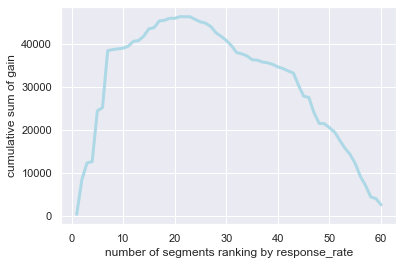

```python
rfm_tpm = pd.read_sql_query('SELECT * FROM rfm_tpm',engine)
rfm_tpm["contact_rate"] = rfm_tpm.cont_cust/rfm_tpm.seg_cust_num
rfm_tpm["cont_response_rate"] = rfm_tpm.seg_total_responded_contact/rfm_tpm.seg_total_contact
rfm_tpm["seg_roi"] = rfm_tpm.seg_total_profit/rfm_tpm.seg_total_cost
rfm_tpm["seg_total_gain"] = rfm_tpm.seg_total_profit - rfm_tpm.seg_total_cost
rfm_tpm = rfm_tpm.sort_values(by='cont_response_rate',axis = 0,ascending = False)
rfm_tpm["cumsum_gain"] = rfm_tpm.seg_total_gain.cumsum()
rfm_tpm = rfm_tpm.reset_index(drop = True)
rfm_tpm = rfm_tpm[['rfm_cell', 'seg_cust_num', 'cont_cust', 'contact_rate', 'res_cust',
       'seg_total_responded_contact', 'seg_total_contact', 'cont_response_rate', 'seg_total_cost',
       'seg_total_profit', 'seg_roi', 'seg_total_gain', 'cumsum_gain']]
rfm_tpm.to_sql('rfm_overall_summary',engine,if_exists='replace',index=False)

plt.plot(range(1,61), rfm_tpm.iloc[:60,:].cumsum_gain, color='lightblue', linewidth=3)
plt.ylabel("cumulative sum of gain")
plt.xlabel("number of segments ranking by response_rate")
```

```python
rfm_tpm[['rfm_cell', 'seg_cust_num','cont_response_rate', 'seg_total_cost',
         'seg_total_profit', 'seg_roi', 'seg_total_gain', 'cumsum_gain']].head()
```

|  | rfm_cell | seg_cust_num | cont_response_rate | seg_total_cost | seg_total_profit | seg_roi | seg_total_gain | cumsum_gain |
| --- | --- | --- | --- | --- | --- | --- | --- | --- |
| 0 | 512 | 291 | 0.064516 | 310.0 | 600.0 | 1.935484 | 290.0 | 290.0 |
| 1 | 553 | 451 | 0.063510 | 7920.0 | 15990.0 | 2.018939 | 8070.0 | 8360.0 |
| 2 | 552 | 305 | 0.062517 | 3711.0 | 7590.0 | 2.045271 | 3879.0 | 12239.0 |
| 3 | 513 | 371 | 0.059952 | 417.0 | 750.0 | 1.798561 | 333.0 | 12572.0 |
| 4 | 554 | 559 | 0.059818 | 12120.0 | 23880.0 | 1.970297 | 11760.0 | 24332.0 |

```python
optimal = rfm_tpm.cumsum_gain.idxmax()+1
print("The optimal gain will be reached when we take the first %f segments"%(optimal))
optimal_list = list(rfm_tpm.rfm_cell)[:optimal]
print("And the concrete segments are shown as following:")
print(optimal_list)
```

```
The optimal gain will be reached when we take the first 21.000000 segments
And the concrete segments are shown as following:
['512', '553', '552', '513', '554', '551', '555', '515', '533', '514', '542', '544', '535', '452', '453', '451', '454', '543', '545', '534', '455']
```

```python
total_order_num = pd.read_sql_query('SELECT DISTINCT("OrderNum") FROM order_dollar',engine).shape[0]
total_profit_past = total_order_num * 30
budget = total_profit_past * 0.05
print("Since overall we have earned %f dollars and if we assume 5 percent of profit as our marketing budget, it will be %f dollars."%(total_profit_past,budget))
```

```
Since overall we have earned 7217430.000000 dollars and if we assume 5 percent of profit as our marketing budget, it will be 360871.500000 dollars.
```

### Step 4: Validation

It involves validating results produced as part of analysis performed on 30% of train data. 70% of remaning data will be used for validation of analysis.

Since we might not have contact data for every one in the dataset although we suppose to mail them all, we calculated based on the data we have and assume it as a customer feature for the whole segment while sending all.

```python
target_cell = rfm_tpm[['rfm_cell', 'cont_response_rate']][:optimal]
target_cell.to_sql('target',engine,if_exists='replace',index=False)
```

```
CREATE OR REPLACE VIEW sub_rfm AS(
SELECT test_df."Cust_ID", target.rfm_cell FROM
target INNER JOIN rfm
ON target.rfm_cell = rfm.rfm_cell
INNER JOIN test_df
ON test_df."Cust_ID" = rfm."Cust_ID"
)
```

```
CREATE OR REPLACE VIEW test_contact_res AS(
SELECT rfm_cell,sub_rfm."Cust_ID",responded_contact_num, responded_order_num, not_responded_contact_num
    FROM sub_rfm
    LEFT JOIN
        (SELECT "Cust_ID", COUNT("ContactDate") AS responded_contact_num, SUM(order_related) AS responded_order_num
        FROM contact_ordernum
        WHERE order_related > 0
        GROUP BY "Cust_ID") AS responded_contact
    ON sub_rfm."Cust_ID" = responded_contact."Cust_ID"
    LEFT JOIN
        (SELECT "Cust_ID", COUNT("ContactDate") AS not_responded_contact_num
        FROM contact_ordernum
        WHERE order_related = 0
        GROUP BY "Cust_ID") AS not_responded_contact
    ON sub_rfm."Cust_ID" = not_responded_contact."Cust_ID")
```

```python
test_contact_res = pd.read_sql_query('SELECT * FROM test_contact_res',engine)
test_contact_res = test_contact_res.fillna(0)
test_contact_res["total_contact_num"] = test_contact_res.responded_contact_num + test_contact_res.not_responded_contact_num
test_contact_res = test_contact_res[['Cust_ID', 'rfm_cell', 'responded_contact_num',
       'not_responded_contact_num','total_contact_num','responded_order_num']]

def binary(x):
    if x > 0: return 1
    else: return 0

test_contact_res["respond_or_not"] = test_contact_res.responded_order_num.apply(binary)
test_contact_res["contact_or_not"] = test_contact_res.total_contact_num.apply(binary)
test_contact_res["mail_cost"] = test_contact_res.total_contact_num*1
test_contact_res["order_profit"] = test_contact_res.responded_order_num * 30
test_contact_res.to_sql('test_contact_res_new',engine,if_exists='replace',index=False)
```

```python
sum(test_contact_res.total_contact_num) < budget # contact number in test set
```

```
True
```

```python
test_contact_res.shape[0] < budget #customer number in test set
```

```
True
```

```
CREATE OR REPLACE VIEW rfm_test AS(
SELECT rfm_cell, COUNT(DISTINCT "Cust_ID") AS seg_cust_num,
        SUM(contact_or_not) AS cont_cust, SUM(respond_or_not) AS res_cust,
        SUM(responded_contact_num) AS seg_total_responded_contact, SUM(total_contact_num) AS seg_total_contact,
        SUM(mail_cost) AS seg_total_cost, SUM(order_profit) AS seg_total_profit
        FROM test_contact_res_new
        GROUP BY rfm_cell
        ORDER BY rfm_cell DESC)
```

```python
rfm_val = pd.read_sql_query('SELECT * FROM rfm_test',engine)
rfm_val["contact_rate"] = rfm_val.cont_cust/rfm_val.seg_cust_num
rfm_val["cont_response_rate"] = rfm_val.seg_total_responded_contact/rfm_val.seg_total_contact
rfm_val["seg_roi"] = rfm_val.seg_total_profit/rfm_val.seg_total_cost
rfm_val["seg_total_gain"] = rfm_val.seg_total_profit - rfm_val.seg_total_cost
rfm_val = rfm_val.sort_values(by='cont_response_rate',axis = 0,ascending = False)
rfm_val["cumsum_gain"] = rfm_val.seg_total_gain.cumsum()
rfm_val = rfm_val.reset_index(drop = True)
rfm_val = rfm_val[['rfm_cell', 'seg_cust_num', 'cont_cust', 'contact_rate', 'res_cust',
       'seg_total_responded_contact', 'seg_total_contact', 'cont_response_rate', 'seg_total_cost',
       'seg_total_profit', 'seg_roi', 'seg_total_gain', 'cumsum_gain']]
rfm_val.to_sql('rfm_validation_summary',engine,if_exists='replace',index=False)
```

```python
rfm_val.head()
```

|  | rfm_cell | seg_cust_num | cont_cust | contact_rate | res_cust | seg_total_responded_contact | seg_total_contact | cont_response_rate | seg_total_cost | seg_total_profit | seg_roi | seg_total_gain | cumsum_gain |
| --- | --- | --- | --- | --- | --- | --- | --- | --- | --- | --- | --- | --- | --- |
| 0 | 513 | 868 | 146.0 | 0.168203 | 59.0 | 59.0 | 906.0 | 0.065121 | 906.0 | 1770.0 | 1.953642 | 864.0 | 864.0 |
| 1 | 551 | 372 | 272.0 | 0.731183 | 101.0 | 145.0 | 2399.0 | 0.060442 | 2399.0 | 4860.0 | 2.025844 | 2461.0 | 3325.0 |
| 2 | 515 | 1098 | 187.0 | 0.170310 | 70.0 | 71.0 | 1232.0 | 0.057630 | 1232.0 | 2130.0 | 1.728896 | 898.0 | 4223.0 |
| 3 | 553 | 1055 | 938.0 | 0.889100 | 600.0 | 1089.0 | 18943.0 | 0.057488 | 18943.0 | 35010.0 | 1.848176 | 16067.0 | 20290.0 |
| 4 | 554 | 1306 | 1192.0 | 0.912711 | 833.0 | 1597.0 | 28641.0 | 0.055759 | 28641.0 | 51630.0 | 1.802661 | 22989.0 | 43279.0 |

```python
print("Before targeting, our average response rate is %f %% while after that, it raised to %f %%"%(np.mean(rfm_tpm.cont_response_rate)*100,np.mean(rfm_val.cont_response_rate)*100))
```

```
Before targeting, our average response rate is 1.429098 % while after that, it raised to 4.515988 %
```

```python
pre_roi = sum(rfm_tpm.seg_total_profit)/sum(rfm_tpm.seg_total_cost)
post_roi = sum(rfm_val.seg_total_profit)/sum(rfm_val.seg_total_cost)
print("Before targeting, our overall ROI is %f while after that, it raised to %f"%(pre_roi,post_roi))
print("ROI is calculated as profit/cost.")
```

```
Before targeting, our overall ROI is 0.615353 while after that, it raised to 1.430525
ROI is calculated as profit/cost.
```

```python
print("To be more concise, in all, we sent totally %d emails (1$ for each) while earning profit %d dollars. %d dollars gain is reached."%(sum(rfm_val.seg_total_contact),sum(rfm_val.seg_total_profit),rfm_val.iat[-1,-1]))
```

```
To be more concise, in all, we sent totally 214956 emails (1$ for each) while earning profit 307500 dollars. 92544 dollars gain is reached.
```

**List of Findings :**